# Chapter 3 – Logistic regression

```
## [1] "Thu Nov 12 19:11:20 2020"
```

## 3.1 Data wrangling

On this part: - merge downloaded datasets and keep students existing both datasets - define high alcohol consumption

Data source: https://archive.ics.uci.edu/ml/datasets/Student+Performance

Here is code:

```r
# Attach library
library(dplyr)

# Change working directory
setwd("~/kursusIODS2020/IODS-project")

# Read 2 datasets from .csv to R
math = read.csv(file = (paste0(getwd(), "/Data/student-mat.csv")), sep=";")
por = read.csv(file = (paste0(getwd(), "/Data/student-por.csv")), sep=";")

dim(math)  # check data
dim(por)
str(math)
str(por)

# Merge datasets

# Common columns to use as identifiers
join_by = c("school","sex","age","address","famsize","Pstatus", "Medu",
             "Fedu","Mjob","Fjob","reason","nursery","internet")

# Join the two datasets by the selected identifiers,
# keep rows existing in both table
math_por <- inner_join(math, por, by = join_by,
                       suffix = c(".math", ".por"))
# Check new datafile
dim(math_por)
glimpse(math_por)


# Next part will combine two possibly different
# answers to the same questions for each student -
# combine these 'duplicated' answers by taking mean/first answer

# Create a new data frame with only the joined columns
alc <- select(math_por, one_of(join_by))

# The columns in the datasets which were not used for joining the data
notjoined_columns <- colnames(math)[!colnames(math) %in% join_by]

# Print out the columns not used for joining
notjoined_columns

# For every column name not used for joining...
for(column_name in notjoined_columns) {
  # select two columns from 'math_por' with the same original name
  two_columns <- select(math_por, starts_with(column_name))
  # select the first column vector of those two columns
  first_column <- select(two_columns, 1)[[1]]
  # if that first column vector is numeric...
  if(is.numeric(first_column)) {
    # take a rounded average of each row of the two columns and
    # add the resulting vector to the alc data frame
    alc[column_name] <- round(rowMeans(two_columns))
  } else { # else if it's not numeric...
    # add the first column vector to the alc data frame
    alc[column_name] <- first_column
  }
}

# glimpse at the new combined data
glimpse(alc)


# Create new columns -
# - alc_use --  average of weekday and weekend alcohol consumption
# - high_use -- logical if average consumption is more than 2 units

alc <- mutate(alc, alc_use = (Dalc + Walc) / 2)
alc <- mutate(alc, high_use = alc_use > 2)

dim(alc)
# [1] 382  35
str(alc)

# Write data file to locak folder as .csv file
write.csv(alc, file = (paste0(getwd(), "/data/alc.csv")), row.names=F)
```

## 3.2 Logistic regression analysis

Today’s libraries:

```r
library(dplyr); library(tidyr); library(ggplot2); library(Epi)
```

### 3.2.2 Read data

As the result of data merging is not complete there (Reijo’s e-mail) and my time has limits, so I cheat and read data from web:

```r
alc = read.csv(file = "https://github.com/rsund/IODS-project/raw/master/data/alc.csv", sep=",")

dim(alc)
```

```
## [1] 370  51
```

```r
names(alc)
```

```
##  [1] "school"     "sex"        "age"        "address"    "famsize"
##  [6] "Pstatus"    "Medu"       "Fedu"       "Mjob"       "Fjob"
## [11] "reason"     "guardian"   "traveltime" "studytime"  "schoolsup"
## [16] "famsup"     "activities" "nursery"    "higher"     "internet"
## [21] "romantic"   "famrel"     "freetime"   "goout"      "Dalc"
## [26] "Walc"       "health"     "n"          "id.p"       "id.m"
## [31] "failures"   "paid"       "absences"   "G1"         "G2"
## [36] "G3"         "failures.p" "paid.p"     "absences.p" "G1.p"
## [41] "G2.p"       "G3.p"       "failures.m" "paid.m"     "absences.m"
## [46] "G1.m"       "G2.m"       "G3.m"       "alc_use"    "high_use"
## [51] "cid"
```

Data consists information about 370 students.

This data approach student achievement in secondary education of two Portuguese schools. The data attributes include student grades, demographic, social and school related features) and it was collected by using school reports and questionnaires. Two datasets are provided regarding the performance in two distinct subjects: Mathematics (mat) and Portuguese language (por). Purpose is to find model to describe high alcohol consumption.

Complete data description is on this link https://archive.ics.uci.edu/ml/datasets/Student+Performance

### 3.2.3 Variables selection, hypotheses

I selected out variables significantly related with high alcohol consumption.

- *absences* – number of school absences (numeric: from 0 to 93)
- *studytime* – weekly study time (numeric: 1 - <2 hours, 2 - 2 to 5 hours, 3 - 5 to 10 hours, or 4 - >10 hours)
- *reason* – reason to choose this school (nominal: close to ‘home’, school ‘reputation’, ‘course’ preference or ‘other’)
- *sex* – student’s sex - male (M), female (F)

I assume that:

- absences are related with higher alcohol consumption
- longer study time is related with lower probability of high alcohol consumption
- the high alcohol consumption is more reare among these who selected school by reputation and/or course selection compared to home and/or other selection reason
- male students have more frequently high alcohol consumption.

### 3.2.4 Variables and alcohol consumption

We have 111 students with high and 259 low alcohol consumption.

```r
table(alc$high_use)
```

```
##
## FALSE  TRUE
##   259   111
```

**Sex** is significantly related with alcohol consumption p<0.001 (Chi-square test). 40% of males and 21% of females have high alcohol consumption.

```r
pctab(table(alc$sex, alc$high_use), dec=1)
```

```
##
##     FALSE TRUE All   N
##   F    79   21 100 195
##   M    60   40 100 175
```

```r
chisq.test(alc$high_use, alc$sex)$p.value
```

```
## [1] 0.0001120883
```

**Study time** has nice statistically significant (Chi-sq test: p=3.210^{-4} dose-response relationship with alcohol consumption (“more study = less alcohol”).

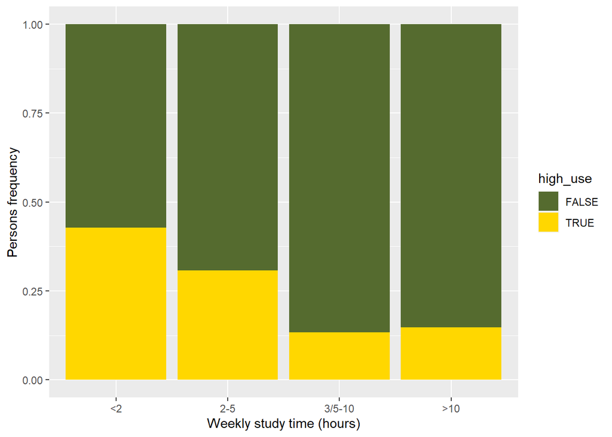

```r
ggplot(data = alc, aes(x = as.factor(studytime), fill = high_use)) +
  geom_bar(position = "fill") +
  scale_fill_manual(values = c("darkolivegreen", "gold")) +
  scale_x_discrete(name = "Weekly study time (hours)",
                  labels = c("<2", "2-5", "3/5-10" ,">10") ) +
  scale_y_continuous(name = "Persons frequency")
```

**Absences** and high alcohol consumption are statistically significantly related (Mann-Whitney test p=3.110^{-4}).

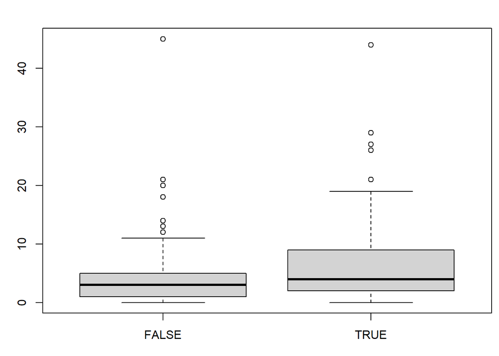

```r
par(mai=c(0.6, 0.6, 0.4, 0.1), cex=1)
boxplot(alc$absences ~ alc$high_use, ylab="No of absences", xlab="High alcohol consumption")
```

**Reason to choose school** is related with high alcohol consumption (p=0.0226704).

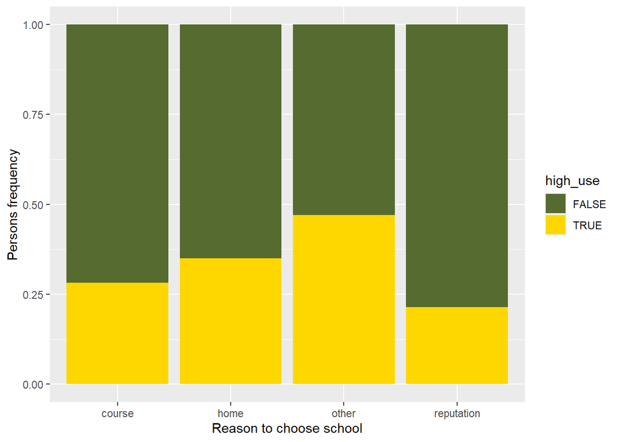

```r
ggplot(data = alc, aes(x = reason, fill = high_use)) +
  geom_bar(position = "fill") +
  scale_fill_manual(values = c("darkolivegreen", "gold")) +
  scale_x_discrete(name = "Reason to choose school") +
  scale_y_continuous(name = "Persons frequency")
```

All my hypotheses are fine.

### 3.2.5 The model

Nice function for better logistic regression output reading

```r
expcoef = function(model)           {
  coeffs <- coef(summary(model))
      or <- exp(coeffs[ ,1])
     lci <- exp(coeffs[ ,1] - 1.96 * coeffs[ ,2])
     uci <- exp(coeffs[ ,1] + 1.96 * coeffs[ ,2])
       p <- round(coeffs[ ,4], 5)
 expcoef <- cbind("OR"=round(or,2),
                  "lci"=round(lci,2),
                  "uci"=round(uci,2), p)
  expcoef
}
```

Estimate logistic regression model and see the output

```r
m <- glm(high_use ~ relevel(as.factor(studytime), 3) + absences +
           relevel(as.factor(reason), "reputation") +  sex, data = alc, family = "binomial")

expcoef(m)
```

```
##                                                  OR  lci  uci       p
## (Intercept)                                    0.06 0.02 0.16 0.00000
## relevel(as.factor(studytime), 3)1              2.62 1.06 6.46 0.03613
## relevel(as.factor(studytime), 3)2              2.22 0.96 5.14 0.06206
## relevel(as.factor(studytime), 3)4              1.15 0.30 4.38 0.83580
## absences                                       1.09 1.04 1.15 0.00018
## relevel(as.factor(reason), "reputation")course 1.43 0.74 2.77 0.28976
## relevel(as.factor(reason), "reputation")home   1.50 0.76 2.95 0.24451
## relevel(as.factor(reason), "reputation")other  3.12 1.26 7.73 0.01372
## sexM                                           2.36 1.41 3.94 0.00104
```

### 3.2.6 Predictions

Add the predicted probabilities to ‘alc’ and make a prediction of high_use (probablities>0.5)

```r
alc <- mutate(alc, probability = predict(m, type = "response"))
alc <- mutate(alc, prediction = probability>0.5)
```

Function that gives target variable versus the predictions, prediction cut-off value is changeable:

```r
confusion = function(ref) {
  table(high_use = alc$high_use, prediction = alc$probability>ref)}
```

Confusion matrix (the target variable versus the predictions) and relative frequencies:

```r
confusion(0.5)
```

```
##         prediction
## high_use FALSE TRUE
##    FALSE   247   12
##    TRUE     80   31
```

```r
confusion(0.5) %>% prop.table %>% addmargins
```

```
##         prediction
## high_use      FALSE       TRUE        Sum
##    FALSE 0.66756757 0.03243243 0.70000000
##    TRUE  0.21621622 0.08378378 0.30000000
##    Sum   0.88378378 0.11621622 1.00000000
```

Calculate relative frequency of incorrect predictions

```r
sum(confusion(0.5)[1,2], confusion(0.5)[2,1])/sum(confusion(0.5))
```

```
## [1] 0.2486486
```

The 66.8% of sample is correctly predicted to low-alcohol group and 8.4% is correctly defined as high-alcohol group. Totally wrong predictions had 24.9% of sample.

Simple testing:

Prediction cut-off point 0 should give all predictions as high-alcohol

```r
confusion(0)
```

```
##         prediction
## high_use TRUE
##    FALSE  259
##    TRUE   111
```

and prediction cut-off point 1 should give all low-alcohol predictions

```r
confusion(1)
```

```
##         prediction
## high_use FALSE
##    FALSE   259
##    TRUE    111
```

It seems working!

Really sorry - no time for bonus exercises on this time. I worked cross-validation throw from DataCamp and I found it useful.